# Lab 10 Activity Key

Author

Published

Invalid Date

### Activity Objectives:

- Two-Way ANOVA

### Instructions:

- Fill in the code chunks
- Render the Quarto document and submit both the `.qmd` and `.html` file on Canvas

## Activity

### 0) If you’d like to load packages with `library()`, please do so in this block.

```r
library(tidyverse)
library(emmeans)
```

```r
pixar <- read_csv(here::here("lab", "data", "lab_10", "pixarfilms_data.csv")) |>
  mutate(id = row_number())
pixar
```

```
# A tibble: 31 × 8
   film            release_date run_time film_rating era   rotten_tomatoes_score
   <chr>           <date>          <dbl> <chr>       <chr>                 <dbl>
 1 Toy Story       1995-11-22         81 G           1990…                   100
 2 A Bug's Life    1998-11-25         95 G           1990…                    92
 3 Toy Story 2     1999-11-24         92 G           1990…                   100
 4 Monsters, Inc.  2001-11-02         92 G           1990…                    96
 5 Finding Nemo    2003-05-30        100 G           1990…                    99
 6 The Incredibles 2004-11-05        115 PG          1990…                    97
 7 Cars            2006-06-09        116 G           1990…                    74
 8 Ratatouille     2007-06-29        111 G           1990…                    96
 9 WALL-E          2008-06-27         98 G           1990…                    95
10 Up              2009-05-29         96 PG          1990…                    98
# ℹ 21 more rows
# ℹ 2 more variables: imdb_score <dbl>, id <int>
```

### 2) Conduct an Two-Way ANOVA examining the effect of decade and film rating on a movie’s IMDB score. Print out the summary and provide a brief (1–2 sentences) interpretation of the results. Justify the choice of Sums of Squares type you made.

```r
options(contrasts = c("contr.sum", "contr.poly"))

m <- aov(imdb_score ~ era * film_rating, data = pixar)
m |>
  car::Anova(type = 3)
```

```
Anova Table (Type III tests)

Response: imdb_score
                Sum Sq Df   F value    Pr(>F)
(Intercept)     997.49  1 3467.0426 < 2.2e-16 ***
era               3.92  1   13.6251 0.0009958 ***
film_rating       0.32  1    1.1269 0.2978388
era:film_rating   0.04  1    0.1547 0.6971351
Residuals         7.77 27
---
Signif. codes:  0 '***' 0.001 '**' 0.01 '*' 0.05 '.' 0.1 ' ' 1
```

### 3) Examine the simple main effects of era on IMDB score within levels of film rating. First, conduct a One-Way ANOVA of the effect of era on IMDB score within each level of film rating.

```r
emms <- emmeans::emmeans(m, specs = c("era", "film_rating"))
emms
```

```
 era         film_rating emmean    SE df lower.CL upper.CL
 1990s-2000s G             7.98 0.179 27     7.61     8.34
 2010s-2020s G             6.92 0.268 27     6.37     7.48
 1990s-2000s PG            8.15 0.379 27     7.37     8.93
 2010s-2020s PG            7.30 0.134 27     7.02     7.58

Confidence level used: 0.95
```

```r
smes_by_era <- emmeans::joint_tests(m, by = "film_rating")
smes_by_era
```

```
film_rating = G:
 model term df1 df2 F.ratio p.value
 era          1  27  10.668  0.0030

film_rating = PG:
 model term df1 df2 F.ratio p.value
 era          1  27   4.464  0.0440
```

### 4) Do you need to conduct additional multiple comparison tests to evaluate pairwise differences? Justify why or why not.

### 5) Visualize the results of your Two-Way ANOVA model.

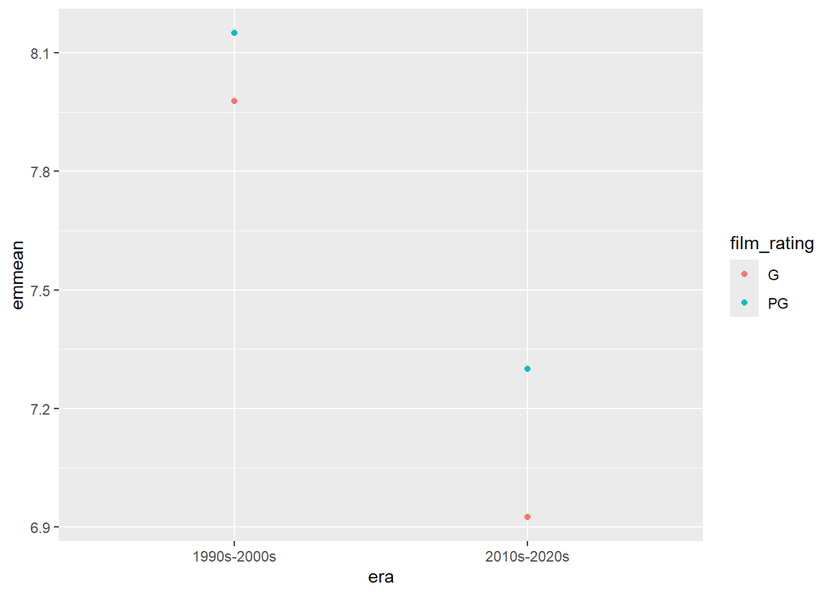

```r
emms |>
  as_tibble() |>
  ggplot(aes(x = era, y = emmean, color = film_rating)) +
  geom_point()
```

## 6) Report your results from this analysis in APA format.